# Using Machine Learning Methods to Predict Wine Quality

## DH 150 Machine Learning Final Project

### Data:

Dataset and its documentation: https://archive.ics.uci.edu/dataset/186/wine+quality

Dataset Description: This dataset is about Vinho Verde wine samples, from the north of Portugal(more info can be found here: https://www.vinhoverde.pt/en/homepage). The data is devided into white and red wine samples. Varaibles in this dataset are mainly related to the physicochemical quality aspect of the wine, in another word, the physical and chemical properties of the wine, such as residual sugar, acidity, density, color, alochol and so on.

### Why I am interested:

- The dataset has practical applications in the world, more specifically, in the food and beverage industry. I am interested in exploring my future carreer in the business analytics domain. Exploring this dataset using ML can be very helpful pratice for me.
- The dataset contains many variables, both categorical and numerical. This will enable to me to use both regression and classification tasks. It would allow me to use a wide range of ML models and approaches.
- The dataset will require potential data preprocessing steps, also model evaluation and optimization later on. These are very pratical and useful applications for me to practice and learn.

### Related published work

"Modeling wine preferences by data mining from physicochemical properties" - link: http://www3.dsi.uminho.pt/pcortez/wine/

This paper proposes an approach to predict human wine taste preferences based on the wine sample data. More specifically, in the wine industry, certification assessment determines and assure wine qualities, which it is key to successful products and maketing. And certification is assessed by physicochemical and sensory tests(variables in dataset). Various machine learning techqiues were applied, such as multipe regression, support vector machine and nerual network, then discussed the advanatges and disadvantages of each model. In the end, the paper discussied models' real world applications and its marketing value.

### Citation

Here below is the citation, as requested by the author for using this dataset:

#### More Information on the dataset

```python
## More Info On The dataset:
file_path = 'winequality.names'

# Open the file and read it line by line
with open(file_path, 'r') as file:
    for line in file:
        print(line, end='')
```

```
Citation Request:
  This dataset is public available for research. The details are described in [Cortez et al., 2009].
  Please include this citation if you plan to use this database:

  P. Cortez, A. Cerdeira, F. Almeida, T. Matos and J. Reis.
  Modeling wine preferences by data mining from physicochemical properties.
  In Decision Support Systems, Elsevier, 47(4):547-553. ISSN: 0167-9236.

  Available at: [@Elsevier] http://dx.doi.org/10.1016/j.dss.2009.05.016
                [Pre-press (pdf)] http://www3.dsi.uminho.pt/pcortez/winequality09.pdf
                [bib] http://www3.dsi.uminho.pt/pcortez/dss09.bib

1. Title: Wine Quality

2. Sources
   Created by: Paulo Cortez (Univ. Minho), Antonio Cerdeira, Fernando Almeida, Telmo Matos and Jose Reis (CVRVV) @ 2009

3. Past Usage:

  P. Cortez, A. Cerdeira, F. Almeida, T. Matos and J. Reis.
  Modeling wine preferences by data mining from physicochemical properties.
  In Decision Support Systems, Elsevier, 47(4):547-553. ISSN: 0167-9236.

  In the above reference, two datasets were created, using red and white wine samples.
  The inputs include objective tests (e.g. PH values) and the output is based on sensory data
  (median of at least 3 evaluations made by wine experts). Each expert graded the wine quality
  between 0 (very bad) and 10 (very excellent). Several data mining methods were applied to model
  these datasets under a regression approach. The support vector machine model achieved the
  best results. Several metrics were computed: MAD, confusion matrix for a fixed error tolerance (T),
  etc. Also, we plot the relative importances of the input variables (as measured by a sensitivity
  analysis procedure).

4. Relevant Information:

   The two datasets are related to red and white variants of the Portuguese "Vinho Verde" wine.
   For more details, consult: http://www.vinhoverde.pt/en/ or the reference [Cortez et al., 2009].
   Due to privacy and logistic issues, only physicochemical (inputs) and sensory (the output) variables
   are available (e.g. there is no data about grape types, wine brand, wine selling price, etc.).

   These datasets can be viewed as classification or regression tasks.
```

[output cut: 17 more lines]

```
   1 - fixed acidity
   2 - volatile acidity
   3 - citric acid
   4 - residual sugar
   5 - chlorides
   6 - free sulfur dioxide
   7 - total sulfur dioxide
   8 - density
   9 - pH
   10 - sulphates
   11 - alcohol
   Output variable (based on sensory data):
   12 - quality (score between 0 and 10)

8. Missing Attribute Values: None
```

```python
# load the data and make some explorations to understand the dataset
import pandas as pd
import numpy as np
```

```python
# two datasets: red wine and white wine
red_wine = pd.read_csv("red.csv", sep=';')
white_wine = pd.read_csv("white.csv", sep=';')
```

```python
print(red_wine.shape)
print(white_wine.shape)
```

```
(1599, 12)
(4898, 12)
```

```python
# red wine data
red_wine.head()
```

|  | fixed acidity | volatile acidity | citric acid | residual sugar | chlorides | free sulfur dioxide | total sulfur dioxide | density | pH | sulphates | alcohol | quality |
| --- | --- | --- | --- | --- | --- | --- | --- | --- | --- | --- | --- | --- |
| 0 | 7.4 | 0.70 | 0.00 | 1.9 | 0.076 | 11.0 | 34.0 | 0.9978 | 3.51 | 0.56 | 9.4 | 5 |
| 1 | 7.8 | 0.88 | 0.00 | 2.6 | 0.098 | 25.0 | 67.0 | 0.9968 | 3.20 | 0.68 | 9.8 | 5 |
| 2 | 7.8 | 0.76 | 0.04 | 2.3 | 0.092 | 15.0 | 54.0 | 0.9970 | 3.26 | 0.65 | 9.8 | 5 |
| 3 | 11.2 | 0.28 | 0.56 | 1.9 | 0.075 | 17.0 | 60.0 | 0.9980 | 3.16 | 0.58 | 9.8 | 6 |
| 4 | 7.4 | 0.70 | 0.00 | 1.9 | 0.076 | 11.0 | 34.0 | 0.9978 | 3.51 | 0.56 | 9.4 | 5 |

```python
# white wine data
white_wine.head()
```

|  | fixed acidity | volatile acidity | citric acid | residual sugar | chlorides | free sulfur dioxide | total sulfur dioxide | density | pH | sulphates | alcohol | quality |
| --- | --- | --- | --- | --- | --- | --- | --- | --- | --- | --- | --- | --- |
| 0 | 7.0 | 0.27 | 0.36 | 20.7 | 0.045 | 45.0 | 170.0 | 1.0010 | 3.00 | 0.45 | 8.8 | 6 |
| 1 | 6.3 | 0.30 | 0.34 | 1.6 | 0.049 | 14.0 | 132.0 | 0.9940 | 3.30 | 0.49 | 9.5 | 6 |
| 2 | 8.1 | 0.28 | 0.40 | 6.9 | 0.050 | 30.0 | 97.0 | 0.9951 | 3.26 | 0.44 | 10.1 | 6 |
| 3 | 7.2 | 0.23 | 0.32 | 8.5 | 0.058 | 47.0 | 186.0 | 0.9956 | 3.19 | 0.40 | 9.9 | 6 |
| 4 | 7.2 | 0.23 | 0.32 | 8.5 | 0.058 | 47.0 | 186.0 | 0.9956 | 3.19 | 0.40 | 9.9 | 6 |

Based on the first look and "more information on the dataset" section above:

we have:

- No missing values
- red wine - 1599; white wine - 4898
- Input variables (based on physicochemical tests): 1 - fixed acidity 2 - volatile acidity 3 - citric acid 4 - residual sugar 5 - chlorides 6 - free sulfur dioxide 7 - total sulfur dioxide 8 - density 9 - pH 10 - sulphates 11 - alcohol Output variable (based on sensory data): 12 - quality (score between 0 and 10)

```python
# More exploratory Analysis
import seaborn as sns
import matplotlib.pyplot as plt
```

Statistical summary of the red and white data:

```python
print(red_wine.describe())
```

```
       fixed acidity  volatile acidity  citric acid  residual sugar  \
count    1599.000000       1599.000000  1599.000000     1599.000000
mean        8.319637          0.527821     0.270976        2.538806
std         1.741096          0.179060     0.194801        1.409928
min         4.600000          0.120000     0.000000        0.900000
25%         7.100000          0.390000     0.090000        1.900000
50%         7.900000          0.520000     0.260000        2.200000
75%         9.200000          0.640000     0.420000        2.600000
max        15.900000          1.580000     1.000000       15.500000

         chlorides  free sulfur dioxide  total sulfur dioxide      density  \
count  1599.000000          1599.000000           1599.000000  1599.000000
mean      0.087467            15.874922             46.467792     0.996747
std       0.047065            10.460157             32.895324     0.001887
min       0.012000             1.000000              6.000000     0.990070
25%       0.070000             7.000000             22.000000     0.995600
50%       0.079000            14.000000             38.000000     0.996750
75%       0.090000            21.000000             62.000000     0.997835
max       0.611000            72.000000            289.000000     1.003690

                pH    sulphates      alcohol      quality
count  1599.000000  1599.000000  1599.000000  1599.000000
mean      3.311113     0.658149    10.422983     5.636023
std       0.154386     0.169507     1.065668     0.807569
min       2.740000     0.330000     8.400000     3.000000
25%       3.210000     0.550000     9.500000     5.000000
50%       3.310000     0.620000    10.200000     6.000000
75%       3.400000     0.730000    11.100000     6.000000
max       4.010000     2.000000    14.900000     8.000000
```

```python
print(white_wine.describe())
```

```
       fixed acidity  volatile acidity  citric acid  residual sugar  \
count    4898.000000       4898.000000  4898.000000     4898.000000
mean        6.854788          0.278241     0.334192        6.391415
std         0.843868          0.100795     0.121020        5.072058
min         3.800000          0.080000     0.000000        0.600000
25%         6.300000          0.210000     0.270000        1.700000
50%         6.800000          0.260000     0.320000        5.200000
75%         7.300000          0.320000     0.390000        9.900000
max        14.200000          1.100000     1.660000       65.800000

         chlorides  free sulfur dioxide  total sulfur dioxide      density  \
count  4898.000000          4898.000000           4898.000000  4898.000000
mean      0.045772            35.308085            138.360657     0.994027
std       0.021848            17.007137             42.498065     0.002991
min       0.009000             2.000000              9.000000     0.987110
25%       0.036000            23.000000            108.000000     0.991723
50%       0.043000            34.000000            134.000000     0.993740
75%       0.050000            46.000000            167.000000     0.996100
max       0.346000           289.000000            440.000000     1.038980

                pH    sulphates      alcohol      quality
count  4898.000000  4898.000000  4898.000000  4898.000000
mean      3.188267     0.489847    10.514267     5.877909
std       0.151001     0.114126     1.230621     0.885639
min       2.720000     0.220000     8.000000     3.000000
25%       3.090000     0.410000     9.500000     5.000000
50%       3.180000     0.470000    10.400000     6.000000
75%       3.280000     0.550000    11.400000     6.000000
max       3.820000     1.080000    14.200000     9.000000
```

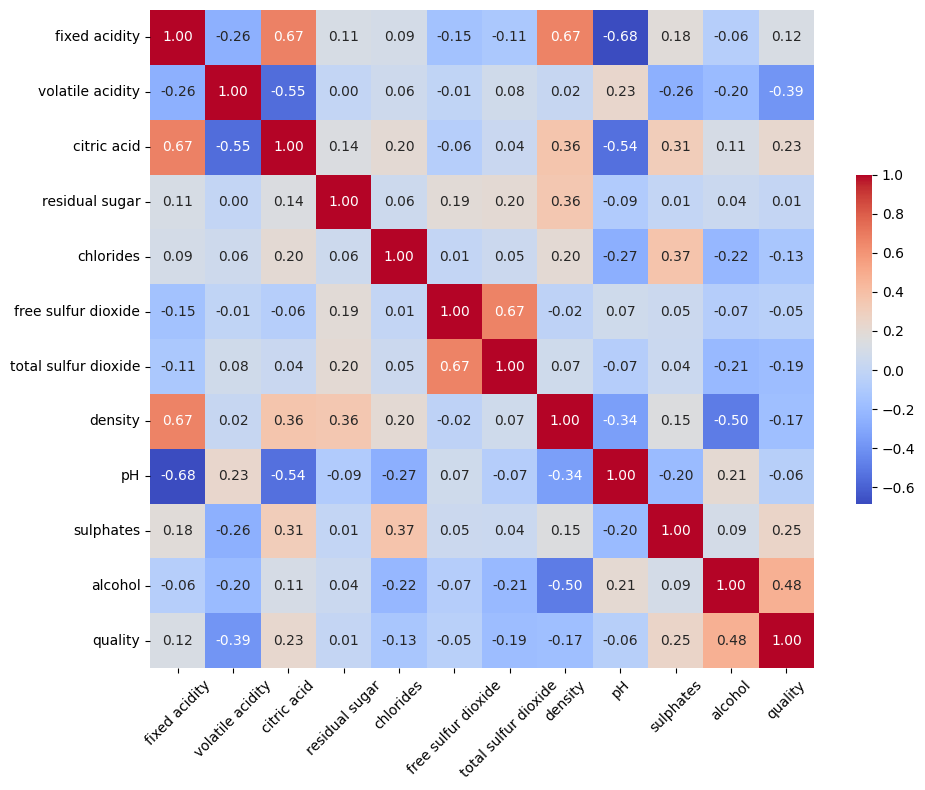

```python
# correlation between physicochemica properties for red wine
corr = red_wine.corr()
# heatmap
plt.figure(figsize=(10, 8))
sns.heatmap(corr, annot=True, fmt=".2f", cmap='coolwarm', cbar_kws={'shrink': .5})
plt.xticks(rotation=45)
plt.tight_layout()
plt.show()
```

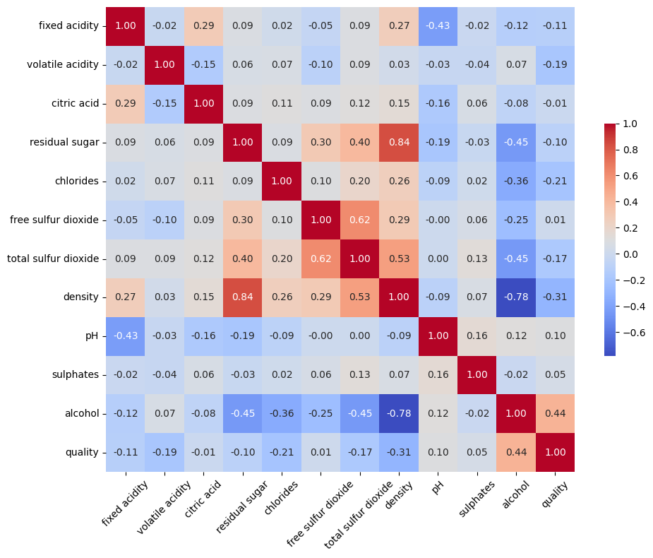

```python
# correlation between physicochemica properties for white wine
corr = white_wine.corr()
# heatmap
plt.figure(figsize=(10, 8))
sns.heatmap(corr, annot=True, fmt=".2f", cmap='coolwarm', cbar_kws={'shrink': .5})
plt.xticks(rotation=45)
plt.tight_layout()
plt.show()
```

Both headmaps show similar patterns interms of correlations heat distributions, for example alcohol has a moderate/strong positive effect on quality for both wines. Density has a moderate/strong negative effect on alcohol.

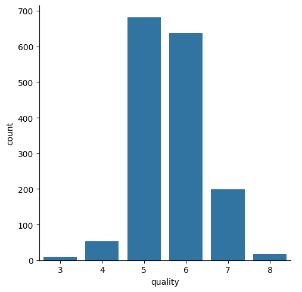

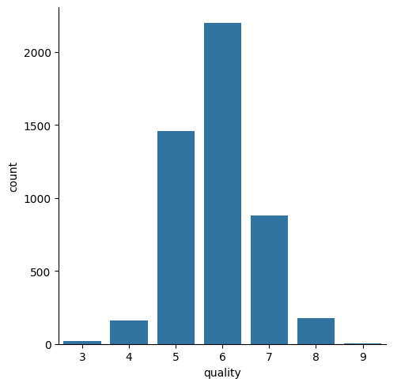

```python
# number of values in each quality
# Red wine:
sns.catplot(x = 'quality', data = red_wine, kind = 'count')
sns.catplot(x = 'quality', data = white_wine, kind = 'count')
```

### Can I predict the quality of the wines from these physiochemical properties?

I decided to use some machine learning methods to see how well I can predict the quality ratings using this wine data. I also decided to combine the red wine and white data and also run models separately to see if any insights on physicochemical properties can be offered.

```python
# combine the red and wine data
combined_wine_data = pd.concat([white_wine, red_wine], ignore_index=True)
combined_wine_data.shape
```

```
(6497, 12)
```

## Linear Regression

All varaibles will be used for the model "quality" will be set as the target

### Scales differences between features

Notice that from the first look of the dataset, we can see that many physicochemical properties have different values. Upon research, I find that for example: free sulfur dioxide might be measured in mg/L and pH is a scale from 0 to 14 and alcohol is typically measured in percentage by volume (% vol). After running the intial model, the performanc is not up to expectation. I decided that further data preprocessing and feature scaling are needed.

```python
from sklearn.model_selection import train_test_split
from sklearn.linear_model import LinearRegression
from sklearn.metrics import mean_squared_error, r2_score
from sklearn.preprocessing import StandardScaler
```

```python
# preprocess data
X_1 = combined_wine_data.drop('quality', axis=1)  # Features
y_1 = combined_wine_data['quality']  # Target

# Split the data into training and testing sets
X_1_train, X_1_test, y_1_train, y_1_test = train_test_split(X_1, y_1, test_size=0.2, random_state=42)
```

```python
# Initialize the scaler
scaler = StandardScaler()

# Fit the scaler to the training data
X_1_train_scaled = scaler.fit_transform(X_1_train)

# Apply to the test data
X_1_test_scaled = scaler.transform(X_1_test)
```

```python
# Initialize the model
model = LinearRegression()

# Fit the model
model.fit(X_1_train_scaled, y_1_train)

y_1_pred = model.predict(X_1_test_scaled)

# mean squared error
mse = mean_squared_error(y_1_test, y_1_pred)
print(f"Mean Squared Error: {mse}")

# R²
r2 = r2_score(y_1_test, y_1_pred)
print(f"R-squared: {r2}")
```

```
Mean Squared Error: 0.4767429335201214
R-squared: 0.33303955208271685
```

The Mean Squared Error and R-squared, indicate that linear regression model does not perform well on the dataset. We want the R-squared to increase and meas sqaured error to decrease.

### Performing linear regression on red and white wine dataset individually

On white wine data:

```python
X_w = white_wine.drop('quality', axis=1)
y_w = white_wine['quality']

X_w_train, X_w_test, y_w_train, y_w_test = train_test_split(X_w, y_w, test_size=0.2, random_state=42)
```

```python
scaler = StandardScaler()

# Fit the scaler to the training data
X_w_train_scaled = scaler.fit_transform(X_w_train)

# Apply to the test data
X_w_test_scaled = scaler.transform(X_w_test)

# Initialize the model
model = LinearRegression()

# Fit the model
model.fit(X_w_train_scaled, y_w_train)

y_w_pred = model.predict(X_w_test_scaled)

# mean squared error
mse = mean_squared_error(y_w_test, y_w_pred)
print(f"Mean Squared Error: {mse}")

# R²
r2 = r2_score(y_w_test, y_w_pred)
print(f"R-squared: {r2}")
```

```
Mean Squared Error: 0.5690247717229254
R-squared: 0.2652750042179155
```

On red wine data:

```python
X_r = red_wine.drop('quality', axis=1)
y_r = red_wine['quality']

X_r_train, X_r_test, y_r_train, y_r_test = train_test_split(X_r, y_r, test_size=0.2, random_state=42)
```

```python
scaler = StandardScaler()

# Fit the scaler to the training data
X_r_train_scaled = scaler.fit_transform(X_r_train)

# Apply to the test data
X_r_test_scaled = scaler.transform(X_r_test)

# Initialize the model
model = LinearRegression()

# Fit the model
model.fit(X_r_train_scaled, y_r_train)

y_r_pred = model.predict(X_r_test_scaled)

# mean squared error
mse = mean_squared_error(y_r_test, y_r_pred)
print(f"Mean Squared Error: {mse}")

# R²
r2 = r2_score(y_r_test, y_r_pred)
print(f"R-squared: {r2}")
```

```
Mean Squared Error: 0.39002514396395493
R-squared: 0.403180341279622
```

From the MSE and R^2, we can see that linear regression model perform slightly better on the red wine dataset. But overall, it is still not up to expectation.

### Random Forest method on wine for quality rating

```python
from sklearn.ensemble import RandomForestClassifier
from sklearn.metrics import accuracy_score
```

```python
X_r = red_wine.drop('quality', axis=1)
y_r = red_wine['quality']

X_r_train, X_r_test, y_r_train, y_r_test = train_test_split(X_r, y_r, test_size=0.2, random_state=42)
model = RandomForestClassifier()
model.fit(X_r_train, y_r_train)
X_r_pred = model.predict(X_r_test)
test_accuracy = accuracy_score(X_r_pred, y_r_test)
print('Accuracy : ', test_accuracy)
```

```
Accuracy :  0.646875
```

```python
X_w = white_wine.drop('quality', axis=1)
y_w = white_wine['quality']

X_w_train, X_w_test, y_w_train, y_w_test = train_test_split(X_w, y_w, test_size=0.2, random_state=42)
model = RandomForestClassifier()
model.fit(X_w_train, y_w_train)
X_w_pred = model.predict(X_w_test)
test_accuracy = accuracy_score(X_w_pred, y_w_test)
print('Accuracy : ', test_accuracy)
```

```
Accuracy :  0.7071428571428572
```

```python
X_c = combined_wine_data.drop('quality', axis=1)
y_c = combined_wine_data['quality']

X_c_train, X_c_test, y_c_train, y_c_test = train_test_split(X_c, y_c, test_size=0.2, random_state=42)
model = RandomForestClassifier()
model.fit(X_c_train, y_c_train)
X_c_pred = model.predict(X_c_test)
test_accuracy = accuracy_score(X_c_pred, y_c_test)
print('Accuracy : ', test_accuracy)
```

```
Accuracy :  0.6923076923076923
```

Random Forest method only achienved about 70% accuracy on the data, which is not up to expectations for predicting the quality of wine in a practical sense.

### Classification

Upon on further examination of the wine dataset, we can see the distribution of wine quality rating is imbalanced. For the interest of research, in real world, most wines are not labeled with numbers, for its quality. It makes more sense to label as the quality of wine useing "good" "premium quality". In this case, for this wine data set, since we have much more data for the white wine, and looking at the quality distribution among the white wine. I have decided to label all wine with a rating higher or equal to "premium quality", and using white wine data as the main research base.

##### Motives for choosing following claasification methods can be found under Analysis Process Section

```python
# Preprocess the data
white_wine['premium_quality'] = (white_wine['quality'] >= 6).astype(int)
# lable above or equal to 6 , to 1 and below rating to 0
white_wine.sample(10)
```

|  | fixed acidity | volatile acidity | citric acid | residual sugar | chlorides | free sulfur dioxide | total sulfur dioxide | density | pH | sulphates | alcohol | quality | premium_quality |
| --- | --- | --- | --- | --- | --- | --- | --- | --- | --- | --- | --- | --- | --- |
| 2998 | 6.0 | 0.320 | 0.30 | 1.30 | 0.025 | 18.0 | 112.0 | 0.98802 | 3.07 | 0.64 | 13.3 | 7 | 1 |
| 2303 | 6.9 | 0.440 | 0.18 | 11.80 | 0.051 | 26.0 | 126.0 | 0.99750 | 3.23 | 0.48 | 9.1 | 5 | 0 |
| 3217 | 5.8 | 0.330 | 0.23 | 5.00 | 0.053 | 29.0 | 106.0 | 0.99458 | 3.13 | 0.52 | 9.0 | 5 | 0 |
| 2626 | 8.0 | 0.240 | 0.26 | 1.70 | 0.033 | 36.0 | 136.0 | 0.99316 | 3.44 | 0.51 | 10.4 | 7 | 1 |
| 1823 | 7.3 | 0.190 | 0.24 | 6.30 | 0.054 | 34.0 | 231.0 | 0.99640 | 3.36 | 0.54 | 10.0 | 6 | 1 |
| 3117 | 6.5 | 0.230 | 0.39 | 1.90 | 0.036 | 41.0 | 98.0 | 0.99000 | 3.19 | 0.43 | 11.9 | 7 | 1 |
| 2319 | 6.6 | 0.400 | 0.32 | 1.70 | 0.035 | 39.0 | 84.0 | 0.99096 | 3.59 | 0.48 | 12.7 | 7 | 1 |
| 288 | 7.2 | 0.230 | 0.39 | 14.20 | 0.058 | 49.0 | 192.0 | 0.99790 | 2.98 | 0.48 | 9.0 | 7 | 1 |
| 4881 | 5.0 | 0.235 | 0.27 | 11.75 | 0.030 | 34.0 | 118.0 | 0.99540 | 3.07 | 0.50 | 9.4 | 6 | 1 |
| 4758 | 6.5 | 0.200 | 0.35 | 3.90 | 0.040 | 27.0 | 140.0 | 0.99102 | 2.98 | 0.53 | 11.8 | 6 | 1 |

### Random Forest for Classification (White Wine)

```python
from sklearn.model_selection import cross_val_score
from sklearn.model_selection import GridSearchCV
from sklearn.metrics import classification_report, recall_score, f1_score
```

```python
# handle data
X = white_wine.drop(['quality', 'premium_quality'], axis = 1)
y = white_wine['premium_quality'] # target
```

```python
X_train, X_test, y_train, y_test = train_test_split(X, y, test_size=0.2, random_state=42)
```

```python
rf = RandomForestClassifier(random_state=42)
rf.fit(X_train, y_train)
```

```
RandomForestClassifier(random_state=42)
```

```python
X_pred = rf.predict(X_test)
test_accuracy = accuracy_score(X_pred, y_test)
print('Accuracy : ', test_accuracy)
```

```
Accuracy :  0.8418367346938775
```

```python
# cross validation:

cv_scores = cross_val_score(rf, X, y, cv=5, scoring='accuracy')

# Print the average score across all folds
print(f"Average CV Accuracy: {cv_scores.mean()}")
```

```
Average CV Accuracy: 0.7523524629463634
```

```python
# The difference between the accuracies suggest hyperparameter tunning maybe needed:
param_grid = {
    'n_estimators': [50, 100, 200, 300],  # Number of trees
    'max_depth': [None, 10, 20, 30],  # Maximum depth
    'max_leaf_nodes' : [None,5,10, 15]
}

# Initialize the grid search
grid_search = GridSearchCV(estimator=rf, param_grid=param_grid, cv=5, scoring='accuracy', n_jobs=-1)

# Fit the grid search to the data
grid_search.fit(X, y)

print(f"Best Parameters: {grid_search.best_params_}")
print(f"Best CV Accuracy: {grid_search.best_score_}")
```

```
Best Parameters: {'max_depth': None, 'max_leaf_nodes': None, 'n_estimators': 200}
Best CV Accuracy: 0.7570469658752162
```

```python
rf_best = RandomForestClassifier(n_estimators=200, max_depth=None, max_leaf_nodes=None, random_state=42)
rf_best.fit(X_train, y_train)
y_pred_best = rf_best.predict(X_test)
test_accuracy_best = accuracy_score(y_test, y_pred_best)
print(f'Accuracy with Best Parameters: {test_accuracy_best}')
```

```
Accuracy with Best Parameters: 0.8418367346938775
```

```python
# Print classification report
print(classification_report(y_test, y_pred_best))

# Calculate recall and F1 score
recall = recall_score(y_test, y_pred_best, average='binary')  # for binary classification
f1 = f1_score(y_test, y_pred_best, average='binary')  # for binary classification

print(f"Recall: {recall}")
print(f"F1 Score: {f1}")
```

```
              precision    recall  f1-score   support

           0       0.78      0.73      0.75       321
           1       0.87      0.90      0.88       659

    accuracy                           0.84       980
   macro avg       0.82      0.81      0.82       980
weighted avg       0.84      0.84      0.84       980

Recall: 0.8983308042488619
F1 Score: 0.8842419716206124
```

```python
# feature importance:
importances = rf_best.feature_importances_
indices = np.argsort(importances)[::-1]
print("Feature ranking:")

for f in range(X_train.shape[1]):
    print(f"{f + 1}. feature {X_train.columns[indices[f]]} ({importances[indices[f]]})")
```

```
Feature ranking:
1. feature alcohol (0.1425536080118508)
2. feature volatile acidity (0.12187922942534213)
3. feature density (0.11040963718144683)
4. feature free sulfur dioxide (0.0958627485199423)
5. feature total sulfur dioxide (0.08572359209784405)
6. feature residual sugar (0.08262451271624155)
7. feature chlorides (0.08080915032706568)
8. feature citric acid (0.08011612802353385)
9. feature pH (0.07195224510341582)
10. feature fixed acidity (0.06470596135466171)
11. feature sulphates (0.06336318723865528)
```

### Logistic regression

```python
from sklearn.linear_model import LogisticRegression
from sklearn.metrics import confusion_matrix
```

```python
X = white_wine.drop(['quality', 'premium_quality'], axis=1)
y = white_wine['premium_quality']  # Target

# Split the data
X_train, X_test, y_train, y_test = train_test_split(X, y, test_size=0.2, random_state=42)

scaler = StandardScaler()
X_scaled = scaler.fit_transform(X)
X_test_scaled = scaler.transform(X_test)
```

```python
# Initialize the model
log_reg = LogisticRegression(max_iter=1000)

# Perform cross-validation
cv_scores = cross_val_score(log_reg, X_scaled, y, cv=5, scoring='accuracy')
print(f"Average CV Accuracy: {cv_scores.mean()}")
```

```
Average CV Accuracy: 0.7358135123303663
```

```python
from sklearn.pipeline import Pipeline

# Define the pipeline
pipeline = Pipeline([
    ('scaler', StandardScaler()),
    ('logreg', LogisticRegression(max_iter=1000))
])

param_grid = {
    'logreg__C': [0.01, 0.1, 1, 10, 100],
    'logreg__solver': ['liblinear', 'lbfgs']
}

# Initialize GridSearchCV with the pipeline and parameter grid
grid_search = GridSearchCV(pipeline, param_grid, cv=5, scoring='accuracy')

# Assuming X and y are already defined
grid_search.fit(X, y)

# Print the best parameters and the best score
print(f"Best Parameters: {grid_search.best_params_}")
print(f"Best CV Score: {grid_search.best_score_}")
```

```
Best Parameters: {'logreg__C': 100, 'logreg__solver': 'lbfgs'}
Best CV Score: 0.7366302557795334
```

```python
# Define the model with the best parameters
best_model = Pipeline([
    ('scaler', StandardScaler()),
    ('logreg', LogisticRegression(C=100, solver='lbfgs', max_iter=1000))
])

# Fit the model on the entire dataset
best_model.fit(X, y)

y_pred_test = best_model.predict(X_test)
test_accuracy = accuracy_score(y_test, y_pred_test)
print(f'Test Set Accuracy: {test_accuracy}')
```

```
Test Set Accuracy: 0.7489795918367347
```

```python
# Print classification report
print(classification_report(y_test, y_pred_test))

# Calculate recall and F1 score
recall = recall_score(y_test, y_pred_test, average='binary')  # for binary classification
f1 = f1_score(y_test, y_pred_test, average='binary')  # for binary classification

print(f"Recall: {recall}")
print(f"F1 Score: {f1}")
```

```
              precision    recall  f1-score   support

           0       0.66      0.49      0.56       321
           1       0.78      0.88      0.82       659

    accuracy                           0.75       980
   macro avg       0.72      0.68      0.69       980
weighted avg       0.74      0.75      0.74       980

Recall: 0.8755690440060698
F1 Score: 0.8242857142857143
```

### Naive Bayes

```python
from sklearn.naive_bayes import GaussianNB
```

```python
# handle data
scaler = StandardScaler()
X_scaled = scaler.fit_transform(X)
X_train_scaled, X_test_scaled, y_train, y_test = train_test_split(X_scaled, y, test_size=0.2, random_state=42)
```

```python
# intialize
gnb = GaussianNB()

# Train the model
gnb.fit(X_train_scaled, y_train)

# Predict on the test set
y_pred = gnb.predict(X_test_scaled)

# Evaluate the model
accuracy = accuracy_score(y_test, y_pred)
print(f'Accuracy: {accuracy}')
```

```
Accuracy: 0.7112244897959183
```

```python
# Perform cross-validation
cv_scores = cross_val_score(gnb, X_scaled, y, cv=5, scoring='accuracy')

# Print the average score across all folds
print(f"Average CV Accuracy: {cv_scores.mean()}")
print(classification_report(y_test, y_pred))
```

```
Average CV Accuracy: 0.6923268224552335
              precision    recall  f1-score   support

           0       0.56      0.57      0.56       321
           1       0.79      0.78      0.78       659

    accuracy                           0.71       980
   macro avg       0.67      0.67      0.67       980
weighted avg       0.71      0.71      0.71       980
```

### Nerual Network

```python
import tensorflow as tf
```

```python
X_train, X_test, y_train, y_test = train_test_split(X, y, test_size=0.2, random_state=42)

# Scale the features
scaler = StandardScaler()
X_train_scaled = scaler.fit_transform(X_train)
X_test_scaled = scaler.transform(X_test)
```

```python
from tensorflow.keras.models import Sequential
from tensorflow.keras.layers import Dense, Dropout

def create_model(n_units, dropout_rate, input_shape):
    model = Sequential([
        Dense(n_units[0], activation='relu', input_shape=(input_shape,)),
        Dropout(dropout_rate),
        Dense(n_units[1], activation='relu'),
        Dropout(dropout_rate),
        Dense(1, activation='sigmoid')
    ])
    model.compile(optimizer='adam', loss='binary_crossentropy', metrics=['accuracy'])
    return model
```

```python
model = create_dnn_model(X_train_scaled.shape[1])

model.compile(optimizer='adam',
              loss='binary_crossentropy',  # Change to 'categorical_crossentropy' for multi-class
              metrics=['accuracy'])
```

```python
history = model.fit(X_train_scaled, y_train,
                    epochs=10,  # Adjust based on the convergence of your model
                    batch_size=32,  # Adjust based on your preference and memory constraints
                    validation_split=0.2,  # Use part of the training data for validation
                    verbose=1)
test_loss, test_acc = model.evaluate(X_test_scaled, y_test, verbose=2)
print('\nTest accuracy:', test_acc)
```

```
31/31 - 0s - loss: 0.4731 - accuracy: 0.7765 - 66ms/epoch - 2ms/step

Test accuracy: 0.7765306234359741
```

```python
hyperparams = {
    'n_units': [(64, 32), (128, 64)],
    'dropout_rate': [0.2, 0.3]
}
best_acc = 0
best_params = {}

for n_units in hyperparams['n_units']:
    for dropout_rate in hyperparams['dropout_rate']:
        # Create and compile the model
        model = create_model(n_units, dropout_rate, X_train_scaled.shape[1])

        # Fit the model
        model.fit(X_train_scaled, y_train, epochs=10, batch_size=32, verbose=0)  # Adjust epochs for full training

        # Evaluate the model
        _, acc = model.evaluate(X_test_scaled, y_test, verbose=0)

        print(f"Units: {n_units}, Dropout: {dropout_rate}, Accuracy: {acc}")

        # Update best params if current model is better
        if acc > best_acc:
            best_acc = acc
            best_params = {'n_units': n_units, 'dropout_rate': dropout_rate}

print(f"Best Accuracy: {best_acc}")
print(f"Best Parameters: {best_params}")
```

```
Units: (64, 32), Dropout: 0.2, Accuracy: 0.7693877816200256
Units: (64, 32), Dropout: 0.3, Accuracy: 0.7622448801994324
Units: (128, 64), Dropout: 0.2, Accuracy: 0.7785714268684387
Units: (128, 64), Dropout: 0.3, Accuracy: 0.7785714268684387
Best Accuracy: 0.7785714268684387
Best Parameters: {'n_units': (128, 64), 'dropout_rate': 0.2}
```

### Decision Tree

```python
from sklearn.tree import DecisionTreeClassifier
```

```python
X_train, X_test, y_train, y_test = train_test_split(X, y, test_size=0.2, random_state=42)
```

```python
# Initialize
dt_classifier = DecisionTreeClassifier(random_state=42)

# Train the classifier on the training data
dt_classifier.fit(X_train, y_train)
```

```
DecisionTreeClassifier(random_state=42)
```

```python
y_pred = dt_classifier.predict(X_test)

# Calculate the accuracy
accuracy = accuracy_score(y_test, y_pred)
print(f"Accuracy: {accuracy}")

# Print a classification report to see precision, recall, and F1-score
print(classification_report(y_test, y_pred))
```

```
Accuracy: 0.7959183673469388
              precision    recall  f1-score   support

           0       0.69      0.68      0.69       321
           1       0.85      0.85      0.85       659

    accuracy                           0.80       980
   macro avg       0.77      0.77      0.77       980
weighted avg       0.79      0.80      0.80       980
```

```python
param_grid = {
    'max_depth': [None, 10, 20, 30, 40, 50],
    'min_samples_split': [2, 5, 10],
    'min_samples_leaf': [1, 2, 4]
}

# Initialize the GridSearchCV
grid_search = GridSearchCV(estimator=DecisionTreeClassifier(random_state=42),
                           param_grid=param_grid,
                           cv=5,  # Number of folds in cross-validation
                           scoring='accuracy',
                           verbose=1)

# Fit
grid_search.fit(X_train, y_train)

print(f"Best Parameters: {grid_search.best_params_}")
print(f"Best CV Score: {grid_search.best_score_}")

# Evaluate the best model
best_model = grid_search.best_estimator_
y_pred_best = best_model.predict(X_test)
print(f"Test Accuracy with Best Parameters: {accuracy_score(y_test, y_pred_best)}")
```

```
Fitting 5 folds for each of 54 candidates, totalling 270 fits
Best Parameters: {'max_depth': None, 'min_samples_leaf': 1, 'min_samples_split': 2}
Best CV Score: 0.7613613261396512
Test Accuracy with Best Parameters: 0.7959183673469388
```

```python
feature_importances = dt_classifier.feature_importances_
features = X.columns
feature_importance_df = pd.DataFrame({'Feature': features, 'Importance': feature_importances})

# Sort the DataFrame by importance in descending order
feature_importance_df = feature_importance_df.sort_values(by='Importance', ascending=False)

print(feature_importance_df)
```

```
                 Feature  Importance
10               alcohol    0.194799
1       volatile acidity    0.128275
5    free sulfur dioxide    0.099248
7                density    0.084084
6   total sulfur dioxide    0.077259
3         residual sugar    0.072609
0          fixed acidity    0.072478
2            citric acid    0.071348
4              chlorides    0.070641
8                     pH    0.070182
9              sulphates    0.059076
```

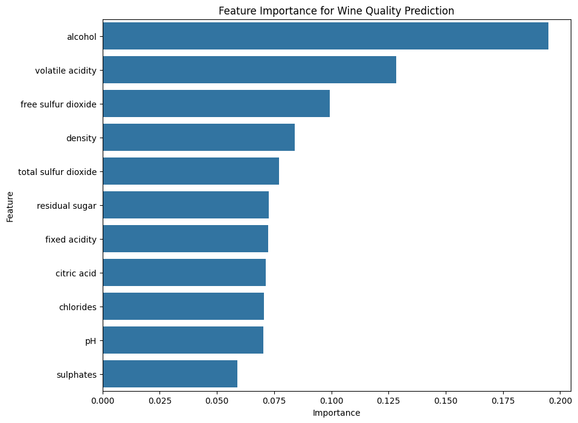

```python
plt.figure(figsize=(10, 8))

# Bar plot of feature importances
sns.barplot(x='Importance', y='Feature', data=feature_importance_df)

plt.title('Feature Importance for Wine Quality Prediction')
plt.xlabel('Importance')
plt.ylabel('Feature')
plt.show()
```

### Model Comparison

```python
# organize
data = {
    'Method': ['Decision Tree', 'Random Forest', 'DNN', 'Naive Bayes', 'Logistic Regression'],
    'Accuracy': [0.7959183673469388, 0.8418367346938775, 0.7785714268684387, 0.7112244897959183, 0.7489795918367347]
}

df = pd.DataFrame(data)
# Sort the DataFrame
df_sorted = df.sort_values(by='Accuracy', ascending=False)

# Reset the index if you want a clean index after sorting
df_sorted.reset_index(drop=True, inplace=True)

# Display the sorted DataFrame
print(df_sorted)
```

```
                Method  Accuracy
0        Random Forest  0.841837
1        Decision Tree  0.795918
2                  DNN  0.778571
3  Logistic Regression  0.748980
4          Naive Bayes  0.711224
```

### Advantages and Disadvantages of Methods Used:

Descision Tree: Decision trees are easy to understand and interpret, making them useful for gaining insights. In our case: which features are most important for predicting wine quality, can be easily discovered. It can model, between features and the target, without needing data transformation. But decision tree is also prone to overfitting. It also can create biased trees if some classes dominate.

Random Forest: Generally provides a significant improvement in accuracy over a single decision tree and less prone to overfitting than individual decision trees. random forests provide insights into feature importance. It is more difficult to interpret than a single decision tree and requires more computational resources and time to train than a single decision tree.

DNN Neural Network: It can model complex non-linear relationships and interactions between features, and easy to work well with large datasets. But without proper regularization and tuning, DNNs can easily overfit to the training data. Typically requires a large amount of data to perform well, which in our case, the dataset is relatively small.

Naive Bayes: It is very easy to implement and understand with working on this dataset, and can perform well in practice despite the simplicity, especially for classification tasks. However, one issue is that it assumes that all features are independent, which is rarely the case in real-world data, making it harder to capture interactions between features.

Logistic Regression: It is fast to train and predict, making it suitable for situations where computational resources are limited. Bur it ussually assumes a linear relationship between the features and the log odds of the outcome, which may not always hold. May further require transformation or feature engineering to capture complex relationships.

Result differences: Models like DNNs and Random Forest can inherently capture complex interactions between features, which might be crucial for accurately predicting wine quality based on physicochemical properties. In contrast, Logistic Regression and Naive Bayes do not naturally model interactions between features unless explicitly defined through feature engineering. Each model comes with its own set of assumptions about the data. For example, Naive Bayes assumes feature independence, and Logistic Regression assumes a linear relationship between features and the log odds of the outcome. If these assumptions do not hold true for the wine dataset, the model's performance can be negatively impacted. Conversely, models like Random Forest and DNNs make fewer assumptions about data distribution, which can sometimes lead to better performance on complex datasets. The capacity to control overfitting through regularization techniques varies among models. DNNs offer various regularization methods. Random Forest controls overfitting through the ensemble method and hyperparameters like the number of trees and maximum depth.

In the context of the wine dataset, with the comparsion of accuracies between these models. Random Forest performs the best, following along with decision tree and and nerual network. Interms of scalability and computational efficiency, DNNs require significant computational resources, especially for large datasets and complex models. Random Forest and Decision Trees can be computationally expensive with very large datasets or a high number of trees and Logistic Regression and Naive Bayes are computationally efficient.

I think overall, concerning all factors, random forest and decsion trees are both suitable options for predicting wine quality.

#### Important Note on Bias, Interpretability, and Ethics:

Interpretability: While complex models like DNN and Random Forests might offer higher accuracy, they often do so at the cost of interpretability. Decision Trees, on the other hand, are more interpretable but might not capture complex relationships as effectively. Also understanding which features are most influential in predicting wine quality can provide insights into the quality prediction.

Ethics: The model is specidically trained on Vinho Verde wine data, which means it does not generalize well on other wine products or company data. And for consumers, reliance on algorithmically determined quality could influence purchasing decisions and potentially limit the diversity of wines they consider. There should be transparency about how models are developed, including the data used, the algorithms applied, and the assumptions made. If any part of the dataset includes or could be linked to individual preferences, opinions, or reviews, it's essential to consider privacy implications. Also note that the quality rating of a wine, is a highly subjective view or opinion, may not fit other people's opinion.

#### Final Model Selection:

I think overall, concerning all factors, random forest and decsion trees are both suitable options for predicting wine quality. (Further analysis on model classification reports can be found in the section below)

## Analysis Process On This Project

After examining the dataset and reading some related research on the subject, and doing some initial research online, I have decided to set my research interest on:

##### How do red wine and white wine differ from one another?

I wanted to look at how physicochemical properties affect the quality of red and white wine differently. I was interested in using generalized models, combining the red and white wine, and evaluate the prediction on quality. Then using individual models trained on separate data of red and white wine, for comparison, in order to gain some insights on the effects of physicochemical properties.

After performing Linear Regression and RandomForest methods on the wine dataset, I have also tried to combine the red wine and white wine dataset, and train my models on the combined dataset, to see if it could offer some insights on the effects of physicochemical properties on the quality of ratings.

##### For the motives and reasons of chose machine learning classification methods:

Decision Tree, Random Forest, DNN, Naive Bayes, and Logistic Regression: for the wine dataset is rooted in a comprehensive approach to address the multifaceted nature of predicting wine quality. Each method brings unique different aspects of the dataset, offering a broad analytical perspectives and predictive capabilities. The Decision Tree was chosen for their simplicity and interpretability. It will provide a straightforward way of understanding how decisions are made, making it easier to explain which features are most influential in determining wine quality. This method is particularly useful when the goal is to gain insights into the decision-making process, such as identifying the physicochemical properties that most significantly impact wine quality. However, Decision Trees can suffer from overfitting, leading to models that perform well on training data but poorly generalize to unseen data. To mitigate the overfitting issue inherent in Decision Trees while still leveraging their interpretability, Random Forest, an ensemble method that combines multiple decision trees, was used. Random Forest improves prediction accuracy and robustness by averaging the predictions of numerous trees, reducing the risk of overfitting and offering a more reliable assessment of feature importance. This method enhances the model's generalization capabilities, making it a strong for achieving higher accuracy in wine quality prediction. DNN was included for their ability to model complex, non-linear relationships between features. DNN is good for capturing intricate patterns in larger datasets, offering the potential for better predictive performance. Their inclusion acknowledges the possibility that the relationships between the physicochemical properties of wines and their quality ratings are complex and might be better captured through deep learning. However, DNNs come with the trade-off of reduced interpretability and increased computational demands. Naive Bayes was chosen for its simplicity and efficiency. Despite its assumption of feature independence, which may not hold true in practice, in our case. But Naive Bayes can perform well in classification tasks. It is good to have a baseline model that is fast to train and can serve as a point of comparison for the more complex models. Lastly, Logistic Regression was selected for its efficiency and the interpretability of its results. It provides a probabilistic framework that is particularly suited for binary classification tasks, such as determining whether a wine is of high or low quality. Logistic Regression models are not only quick to train but also offer insights into the relationship between features and the target variable.

##### Examining the classification report on several used methods:

The classification report for the Random Forest model on the wine dataset reveals a solid performance, particularly in distinguishing between the two classes of wine quality. The model achieves an overall accuracy of 84%, indicating a strong ability to correctly classify wines as either class 0 or class 1. Specifically, the model shows a precision of 0.78 for class 0 (lower quality) and 0.87 for class 1 (higher quality), suggesting it is more reliable in identifying higher quality wines without mistakenly labeling lower quality wines as high quality. The recall scores, 0.73 for class 0 and 0.90 for class 1, indicate that the model is slightly better at identifying most of the higher quality wines than it is at catching all of the lower quality ones. This is further reflected in the F1-scores, which balance precision and recall, showing a score of 0.75 for class 0 and a higher score of 0.88 for class 1. The macro average F1-score of 0.82 and the weighted average of 0.84 suggest a balanced performance across both classes, with a slight favor towards class 1. This indicates the dataset contains more higher quality wine. The classification report for the Decision Tree model applied to the wine dataset indicates a commendable performance, with an overall accuracy of 80%. This suggests that the model is fairly effective at classifying wines into the correct quality categories. Specifically, the model demonstrates a precision of 0.69 for class 0 (lower quality wines) and 0.85 for class 1 (higher quality wines), indicating a stronger capability in correctly identifying higher quality wines as such, compared to its performance on lower quality wines. The recall scores, being 0.68 for class 0 and 0.85 for class 1, mirror this observation, showing that the model is slightly better at capturing the majority of higher quality wines than it is at identifying all lower quality wines. The F1-scores, which are harmonic means of precision and recall, stand at 0.69 for class 0 and 0.85 for class 1, further highlighting the model's proficiency in dealing with higher quality wines. The macro and weighted average F1-scores of 0.77 and 0.80, respectively, reflect a balanced performance across the two classes, with a slight inclination towards better identifying class 1. Compared with RandomForest, decision trees perform on an expected level. The classification report for the Naive Bayes model on the wine dataset illustrates a moderate level of performance, with an overall accuracy of 71%. This indicates that while the model is reasonably effective at distinguishing between the two classes of wine quality, there is significant room for improvement. Specifically, the model exhibits a precision of 0.56 for class 0 (lower quality wines) and 0.79 for class 1 (higher quality wines), suggesting it is more adept at correctly identifying higher quality wines but struggles somewhat with lower quality wines. The recall scores, at 0.57 for class 0 and 0.78 for class 1, reinforce this point, indicating the model is slightly better at capturing the majority of higher quality wines than accurately identifying all lower quality wines. The F1-scores, which aim to balance precision and recall, stand at 0.56 for class 0 and 0.78 for class 1, further highlighting the model's relative proficiency with higher quality wines. The macro and weighted average F1-scores of 0.67 and 0.71, respectively, suggest a balanced yet modest performance across both classes, with a noticeable bias towards better handling of class 1. The classification report for the Logistic Regression model applied to the wine dataset indicates a satisfactory performance with an overall accuracy of 75%. This level of accuracy suggests that the model is relatively effective at classifying wines into their correct quality categories, albeit with some limitations. Specifically, the model shows a precision of 0.66 for class 0 (lower quality wines) and 0.78 for class 1 (higher quality wines), indicating a more reliable performance in identifying higher quality wines as such, compared to lower quality wines. The recall scores, 0.49 for class 0 and 0.88 for class 1, highlight a significant disparity in the model's ability to capture all instances of lower quality wines versus higher quality wines, with a notably better performance in recognizing the latter. The F1-scores, standing at 0.56 for class 0 and 0.82 for class 1, further underscore the model's proficiency in dealing with higher quality wines, while also pointing to a need for improvement in accurately classifying lower quality wines. The macro average F1-score of 0.69 and the weighted average of 0.74 reflect a moderate performance across both classes, with a clear inclination towards better handling of class 1.

##### Possible Improvements Approached in the future (many suggestions are based from researches under References)

Improving the models used for predicting wine quality in future endeavors involves a multifaceted approach that encompasses data enrichment, advanced modeling techniques, and comprehensive evaluation strategies. Firstly, expanding the dataset can significantly enhance model performance. This could involve collecting more samples to increase the dataset's size, which helps deep learning models learn more complex patterns, or incorporating additional features that may influence wine quality。Secondly, exploring advanced modeling techniques and architectures offers another avenue for improvement. For instance, ensemble methods beyond Random Forest, such as Gradient Boosting Machines (GBM) or Extreme Gradient Boosting (XGBoost), can provide better performance by systematically addressing model biases and variances. Similarly, experimenting with deeper or more complex neural network architectures, including recurrent neural networks (RNNs) for sequential data patterns or attention mechanisms to focus on influential features, could uncover nuanced relationships within the data. Additionally, leveraging unsupervised learning techniques for feature extraction or dimensionality reduction, such as principal component analysis (PCA), might reveal underlying patterns not immediately apparent, enhancing model inputs. Also refining the hyperparameter tuning process is very important/ Utilizing more sophisticated techniques can more efficiently explore the hyperparameter space, potentially uncovering optimal configurations that were previously overlooked. Implementing cross-validation more rigorously, evaluation is robust and generalizes well to unseen data.

## References:

@inproceedings{Angus2019ModelingWQ, title={Modeling Wine Quality from Physicochemical Properties}, author={D. C. Angus}, year={2019}, url={https://api.semanticscholar.org/CorpusID:209521363} }

@article{Cortez2009ModelingWP, title={Modeling wine preferences by data mining from physicochemical properties}, author={P. Cortez and Antonio Lu{\'i}z Cerdeira and Fernando Almeida and Telmo Matos and Jos{\'e} Reis}, journal={Decis. Support Syst.}, year={2009}, volume={47}, pages={547-553}, url={https://api.semanticscholar.org/CorpusID:2996254} }

@inproceedings{Zeng2023TheCO, title={The classification of red wine quality based on machine learning techniques}, author={Ming Zeng}, booktitle={Other Conferences}, year={2023}, url={https://api.semanticscholar.org/CorpusID:257826903} }